# Nebraska Student Absenteeism — EDA 2020/21

**Source:** Nebraska Department of Education — Data & Information Archives  
**Team:** SP_2026_Team-B Abhinav Adhikari [Individual] **Scope:** Statewide K–12 absence patterns by grade, race, poverty, and gender

```python
import io, os, warnings
import numpy as np
import pandas as pd
import matplotlib.pyplot as plt
import matplotlib.patches as mpatches
import matplotlib.ticker as mticker
import seaborn as sns
warnings.filterwarnings('ignore')

NAVY   = '#0a1628'
BLUE   = '#2d7dd2'
TEAL   = '#1a9e8f'
AMBER  = '#f0a500'
ORANGE = '#e07b39'
RED    = '#c0392b'
MUTED  = '#8a9ab5'
PAL    = [BLUE, AMBER, ORANGE, RED, TEAL, '#7b5ea7', MUTED]

plt.rcParams.update({
    'figure.facecolor': NAVY,
    'axes.facecolor':   '#112240',
    'axes.edgecolor':   '#1e3a5f',
    'axes.labelcolor':  MUTED,
    'xtick.color':      MUTED,
    'ytick.color':      MUTED,
    'text.color':       'white',
    'grid.color':       '#1e3a5f',
    'grid.linewidth':   0.5,
    'axes.spines.top':  False,
    'axes.spines.right':False,
    'font.size':        11,
    'axes.titlesize':   13,
    'axes.titleweight': 'bold',
    'figure.dpi':       120,
})
```

## 1. Data Loading

Update `DATA_DIR` to your local path.

```python
DATA_DIR = r'C:\Users\97603045\Documents\github\SP_2026_Team-B\Source_File'

ATT_FILE = os.path.join(DATA_DIR, '2020-2021-Student-Absences-Counts-by-District (2).xlsx')
MBR_FILE = os.path.join(DATA_DIR, 'MembershipByGradeRaceAndGender_20202021.csv')
CTY_FILE = os.path.join(DATA_DIR, 'CountyMembershipByGrade_20202021.csv')

MBR_URL = 'https://www.education.ne.gov/wp-content/uploads/2020/11/MembershipByGradeRaceAndGender_20202021.csv'
CTY_URL = 'https://www.education.ne.gov/wp-content/uploads/2020/11/CountyMembershipByGrade_20202021.csv'

def load_csv(local_path, url):
    if os.path.exists(local_path):
        print(f'  Loading local: {os.path.basename(local_path)}')
        return pd.read_csv(local_path)
    import requests
    print(f'  Downloading: {url}')
    r = requests.get(url, headers={'User-Agent':'Mozilla/5.0'}, timeout=60)
    return pd.read_csv(io.BytesIO(r.content))

raw_att = pd.read_excel(ATT_FILE, header=None)
raw_mbr = load_csv(MBR_FILE, MBR_URL)
raw_cty = load_csv(CTY_FILE, CTY_URL)

print(f'Attendance file : {raw_att.shape}')
print(f'Membership file : {raw_mbr.shape}')
print(f'County file     : {raw_cty.shape}')
```

```
  Downloading: https://www.education.ne.gov/wp-content/uploads/2020/11/MembershipByGradeRaceAndGender_20202021.csv
  Downloading: https://www.education.ne.gov/wp-content/uploads/2020/11/CountyMembershipByGrade_20202021.csv
Attendance file : (61, 10)
Membership file : (7030, 29)
County file     : (1255, 24)
```

## 2. Parse Attendance File

Five stacked tables extracted from the Excel file.

```python
COLS = ['group','membership','abs10','pct10','abs15','pct15','abs20','pct20','chronic_n','chronic_pct']

def extract_block(df, start_row, nrows):
    rows = []
    for i in range(start_row, start_row + nrows):
        vals = df.iloc[i].dropna().tolist()
        if len(vals) >= 9:
            rows.append(vals[:10])
    out = pd.DataFrame(rows, columns=COLS)
    for c in COLS[1:]: out[c] = pd.to_numeric(out[c], errors='coerce')
    out['chronic_pct'] = out['chronic_pct'] * 100
    out['pct10'] = out['pct10'] * 100
    out['pct15'] = out['pct15'] * 100
    out['pct20'] = out['pct20'] * 100
    return out

by_grade    = extract_block(raw_att, 15, 13)
by_race     = extract_block(raw_att, 31,  7)
by_gender   = extract_block(raw_att, 42,  2)
by_poverty  = extract_block(raw_att, 47,  2)
by_pov_race = extract_block(raw_att, 53,  7)

# Statewide totals — from attendance file rows 8-12
TOTAL_ENROLLED = 306623
CHRONIC_TOTAL  = 63958
ABS10_TOTAL    = 111910
ABS15_TOTAL    = 68520
ABS20_TOTAL    = 44292

print('by_grade:')
print(by_grade[['group','membership','chronic_n','chronic_pct']].to_string())
print('\nby_race:')
print(by_race[['group','membership','chronic_n','chronic_pct']].to_string())
print('\nby_poverty:')
print(by_poverty[['group','membership','chronic_n','chronic_pct']].to_string())
```

```
by_grade:
   group  membership  chronic_n  chronic_pct
0     KG       22894       3767    16.454093
1     01       23035       3279    14.234860
2     02       22705       2992    13.177714
3     03       22939       3104    13.531540
4     04       22855       3071    13.436885
5     05       23511       3491    14.848369
6     06       24122       4191    17.374181
7     07       24291       5017    20.653740
8     08       22782       5081    22.302695
9     09       24159       6229    25.783352
10    10       24296       7065    29.078861
11    11       24008       7754    32.297567
12    12       25026       8917    35.630944

by_race:
                                       group  membership  chronic_n  chronic_pct
0           AMERICAN INDIAN OR ALASKA NATIVE        3866       2232    57.734092
1                                      ASIAN        8954       1086    12.128658
2                  BLACK OR AFRICAN AMERICAN       20429       8886    43.496990
3                                   HISPANIC       60924      19121    31.385004
4  NATIVE HAWAIIAN OR OTHER PACIFIC ISLANDER         464        175    37.715517
5                          TWO OR MORE RACES       13095       3608    27.552501
6                                      WHITE      198891      28850    14.505433

by_poverty:
               group  membership  chronic_n  chronic_pct
0            POVERTY      134310      46643    34.727868
1  SPECIAL EDUCATION       46036      14433    31.351551
```

## 3. Parse Membership File

```python
mbr = raw_mbr.copy()
mbr.columns = mbr.columns.str.strip()

# Explicit column names from actual file
dist_col  = 'DISTRICT_NAME'
grade_col = 'GRADE_CODE'
race_cols = ['F_WH','M_WH','FBL','M_BL','F_HI','M_HI','F_AS','M_AS',
             'F_AM','M_AM','F_PI','M_PI','F_MU','M_MU']

for c in race_cols:
    mbr[c] = pd.to_numeric(mbr[c], errors='coerce')
mbr['TOTAL'] = pd.to_numeric(mbr['TOTAL'], errors='coerce')

# Combine M+F race columns into single totals
mbr['White']     = mbr['F_WH'] + mbr['M_WH']
mbr['Black']     = mbr['FBL']  + mbr['M_BL']
mbr['Hispanic']  = mbr['F_HI'] + mbr['M_HI']
mbr['Asian']     = mbr['F_AS'] + mbr['M_AS']
mbr['Am.Indian'] = mbr['F_AM'] + mbr['M_AM']
mbr['Pac.Isl.']  = mbr['F_PI'] + mbr['M_PI']
mbr['Multi']     = mbr['F_MU'] + mbr['M_MU']
demo_cols = ['White','Black','Hispanic','Asian','Am.Indian','Pac.Isl.','Multi']

# School level mapping
def grade_to_level(g):
    g_s = str(g).strip().upper().lstrip('0') or '0'
    if g_s in {'PK','KD','KG','K','0','1','2','3','4','5'}: return 'Elementary'
    if g_s in {'6','7','8'}:                                 return 'Middle'
    if g_s in {'9','10','11','12'}:                          return 'High School'
    return 'Other'

mbr['level'] = mbr[grade_col].apply(grade_to_level)

print(f'Districts : {mbr[dist_col].nunique()}')
print(f'Grades    : {sorted(mbr[grade_col].dropna().unique().tolist())}')
print(f'Demo cols : {demo_cols}')
```

```
Districts : 408
Grades    : ['01', '02', '03', '04', '05', '06', '07', '08', '09', '10', '11', '12', 'K ', 'PK']
Demo cols : ['White', 'Black', 'Hispanic', 'Asian', 'Am.Indian', 'Pac.Isl.', 'Multi']
```

## 4. The Absence Problem

**Key question:** How many Nebraska students are missing school and how severely?

> 1 in 5 Nebraska K–12 students is chronically absent — missing 10% or more of the school year.

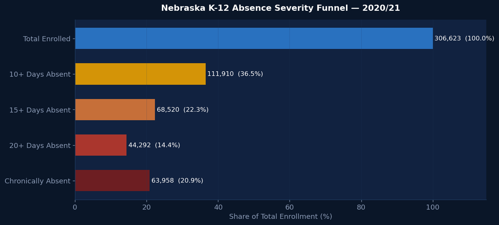

```python
# ── CHART 1: Absence Severity Funnel ────────────────────────────────────
fig, ax = plt.subplots(figsize=(11, 5))

labels = ['Total Enrolled', '10+ Days Absent', '15+ Days Absent', '20+ Days Absent', 'Chronically Absent']
counts = [TOTAL_ENROLLED, ABS10_TOTAL, ABS15_TOTAL, ABS20_TOTAL, CHRONIC_TOTAL]
pcts   = [c / TOTAL_ENROLLED * 100 for c in counts]
colors = [BLUE, AMBER, ORANGE, RED, '#7b1e1e']

for i, (label, count, pct, color) in enumerate(zip(labels, counts, pcts, colors)):
    ax.barh(i, pct, color=color, alpha=0.88, height=0.6, edgecolor='none')
    ax.text(pct+0.5, i, f'{count:,}  ({pct:.1f}%)', va='center', fontsize=10, color='white')

ax.set_yticks(range(len(labels)))
ax.set_yticklabels(labels, fontsize=11)
ax.set_xlabel('Share of Total Enrollment (%)')
ax.set_xlim(0, 115)
ax.set_title('Nebraska K-12 Absence Severity Funnel — 2020/21', pad=14)
ax.invert_yaxis()
ax.grid(axis='x', alpha=0.3)
plt.tight_layout()
plt.savefig('fig01_funnel.png', bbox_inches='tight', facecolor=NAVY)
plt.show()
```

```
Not significantly absent: 194,713
10–15 days: 43,390
15–20 days: 24,228
20+ days: 44,292
Chronically absent: 63,958
```

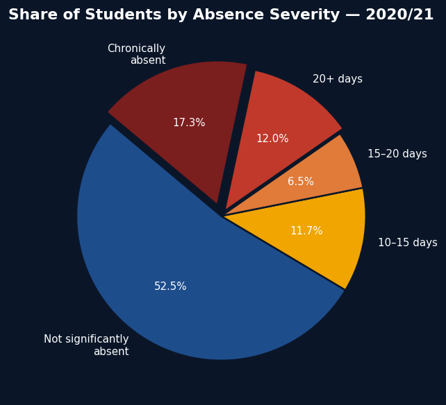

```python
# ── CHART 2: Absence breakdown donut ─────────────────────────────────────
fig, ax = plt.subplots(figsize=(7, 5))

# These are independent counts — students who fall into each bucket
# "Not significantly absent" = enrolled but not in any absence category
not_absent = TOTAL_ENROLLED - ABS10_TOTAL
tier_10_15 = ABS10_TOTAL - ABS15_TOTAL
tier_15_20 = ABS15_TOTAL - ABS20_TOTAL
tier_20    = ABS20_TOTAL
# Note: chronic (10%+ of year) overlaps with the above — show separately
# Use only the non-overlapping tiers + chronic as its own slice
sizes  = [not_absent, tier_10_15, tier_15_20, tier_20, CHRONIC_TOTAL]
labels = ['Not significantly\nabsent','10–15 days','15–20 days','20+ days','Chronically\nabsent']
colors = ['#1e4d8c', AMBER, ORANGE, RED, '#7b1e1e']
explode= [0, 0, 0, 0.04, 0.08]

# Safety check — print sizes before plotting
for lbl, sz in zip(labels, sizes):
    print(f'{lbl.replace(chr(10)," ")}: {sz:,}')

wedges, texts, autotexts = ax.pie(
    sizes, labels=labels, colors=colors, explode=explode,
    autopct='%1.1f%%', startangle=140,
    wedgeprops=dict(linewidth=1.5, edgecolor=NAVY),
    textprops=dict(color='white', fontsize=9)
)
for at in autotexts: at.set_fontsize(9)
ax.set_title('Share of Students by Absence Severity — 2020/21', pad=14)
plt.tight_layout()
plt.savefig('fig02_pie.png', bbox_inches='tight', facecolor=NAVY)
plt.show()
```

## 5. Absenteeism by Grade

**Key question:** Where in the K–12 pipeline does absenteeism escalate?

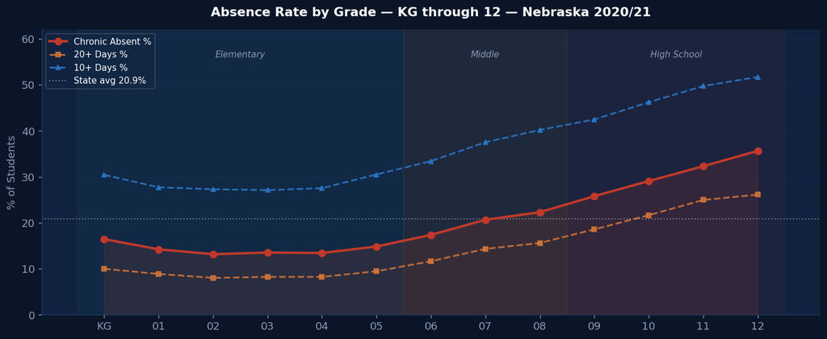

```python
# ── CHART 3: Chronic rate by grade — line chart ──────────────────────────
grades = by_grade['group'].tolist()
x = np.arange(len(grades))

fig, ax = plt.subplots(figsize=(12, 5))
ax.fill_between(x, by_grade['chronic_pct'], alpha=0.15, color=RED)
ax.plot(x, by_grade['chronic_pct'], 'o-', color=RED, linewidth=2.5, markersize=7, label='Chronic Absent %', zorder=3)
ax.plot(x, by_grade['pct20'], 's--', color=ORANGE, linewidth=1.8, markersize=5, alpha=0.8, label='20+ Days %')
ax.plot(x, by_grade['pct10'], '^--', color=BLUE,   linewidth=1.8, markersize=5, alpha=0.8, label='10+ Days %')
ax.axhline(20.9, color='white', linestyle=':', linewidth=1.2, alpha=0.4, label='State avg 20.9%')

ax.axvspan(-0.5, 5.5, alpha=0.06, color=TEAL)
ax.axvspan(5.5,  8.5, alpha=0.06, color=AMBER)
ax.axvspan(8.5, 12.5, alpha=0.06, color=RED)
for x_pos, lbl in [(2.5,'Elementary'),(7,'Middle'),(10.5,'High School')]:
    ax.text(x_pos, 56, lbl, ha='center', fontsize=9, color=MUTED, style='italic')

ax.set_xticks(x); ax.set_xticklabels(grades)
ax.set_ylabel('% of Students'); ax.set_ylim(0, 62)
ax.set_title('Absence Rate by Grade — KG through 12 — Nebraska 2020/21', pad=14)
ax.legend(loc='upper left', fontsize=9, framealpha=0.2)
ax.grid(axis='y', alpha=0.3)
plt.tight_layout()
plt.savefig('fig03_grade_line.png', bbox_inches='tight', facecolor=NAVY)
plt.show()
```

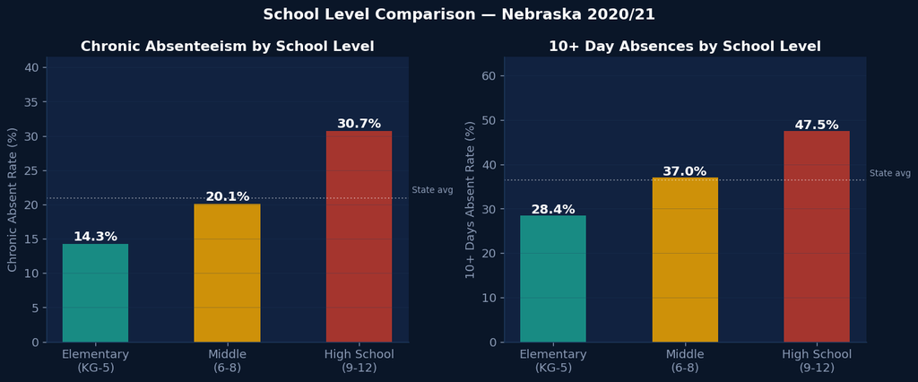

```python
# ── CHART 4: School level summary ────────────────────────────────────────
elem = by_grade.iloc[:6]
mid  = by_grade.iloc[6:9]
high = by_grade.iloc[9:]

def wmean(df, col, wt='membership'):
    return np.average(df[col], weights=df[wt])

level_labels  = ['Elementary\n(KG-5)', 'Middle\n(6-8)', 'High School\n(9-12)']
level_chronic = [wmean(elem,'chronic_pct'), wmean(mid,'chronic_pct'), wmean(high,'chronic_pct')]
level_abs10   = [wmean(elem,'pct10'),       wmean(mid,'pct10'),       wmean(high,'pct10')]
level_colors  = [TEAL, AMBER, RED]

fig, axes = plt.subplots(1, 2, figsize=(12, 5))
for ax, vals, ylabel, title, avg in [
    (axes[0], level_chronic, 'Chronic Absent Rate (%)', 'Chronic Absenteeism by School Level', 20.9),
    (axes[1], level_abs10,   '10+ Days Absent Rate (%)', '10+ Day Absences by School Level',   36.5)
]:
    bars = ax.bar(level_labels, vals, color=level_colors, alpha=0.85, width=0.5, edgecolor='none')
    for bar, val in zip(bars, vals):
        ax.text(bar.get_x()+bar.get_width()/2, bar.get_height()+0.5,
                f'{val:.1f}%', ha='center', fontsize=12, fontweight='bold', color='white')
    ax.axhline(avg, color='white', linestyle=':', linewidth=1.2, alpha=0.4)
    ax.text(2.4, avg+0.8, 'State avg', fontsize=8, color=MUTED)
    ax.set_ylabel(ylabel); ax.set_title(title)
    ax.set_ylim(0, max(vals)*1.35)
    ax.grid(axis='y', alpha=0.3)

fig.suptitle('School Level Comparison — Nebraska 2020/21', fontsize=14, fontweight='bold')
plt.tight_layout()
plt.savefig('fig04_level_compare.png', bbox_inches='tight', facecolor=NAVY)
plt.show()
```

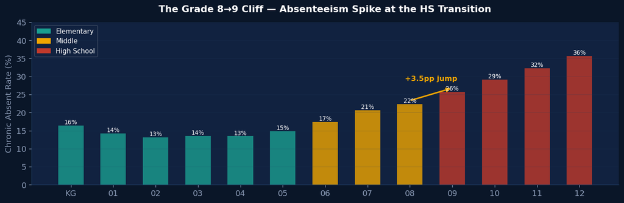

```python
# ── CHART 5: Grade 8→9 cliff ──────────────────────────────────────────────
fig, ax = plt.subplots(figsize=(12, 4))

chronic = by_grade['chronic_pct'].values
bar_colors = [TEAL]*6 + [AMBER]*3 + [RED]*4
ax.bar(x, chronic, color=bar_colors, alpha=0.8, edgecolor='none', width=0.6)

g8_val = chronic[grades.index('08')]
g9_val = chronic[grades.index('09')]
g8_x   = grades.index('08')
g9_x   = grades.index('09')
ax.annotate('', xy=(g9_x, g9_val+1), xytext=(g8_x, g8_val+1),
            arrowprops=dict(arrowstyle='->', color=AMBER, lw=2))
ax.text((g8_x+g9_x)/2, max(g8_val,g9_val)+3,
        f'+{g9_val-g8_val:.1f}pp jump', ha='center', color=AMBER, fontsize=10, fontweight='bold')

for xi, val in zip(x, chronic):
    ax.text(xi, val+0.4, f'{val:.0f}%', ha='center', fontsize=8, color='white')

ax.set_xticks(x); ax.set_xticklabels(grades)
ax.set_ylabel('Chronic Absent Rate (%)')
ax.set_title('The Grade 8→9 Cliff — Absenteeism Spike at the HS Transition', pad=14)
ax.set_ylim(0, 45)
patches = [mpatches.Patch(color=TEAL, label='Elementary'),
           mpatches.Patch(color=AMBER, label='Middle'),
           mpatches.Patch(color=RED,   label='High School')]
ax.legend(handles=patches, fontsize=9, framealpha=0.2)
ax.grid(axis='y', alpha=0.3)
plt.tight_layout()
plt.savefig('fig05_grade8_9_cliff.png', bbox_inches='tight', facecolor=NAVY)
plt.show()
```

## 6. Race & Ethnicity

**Key question:** Which student groups are most affected?

> American Indian/Alaska Native students have a 57.7% chronic absence rate — nearly 3× the state average.

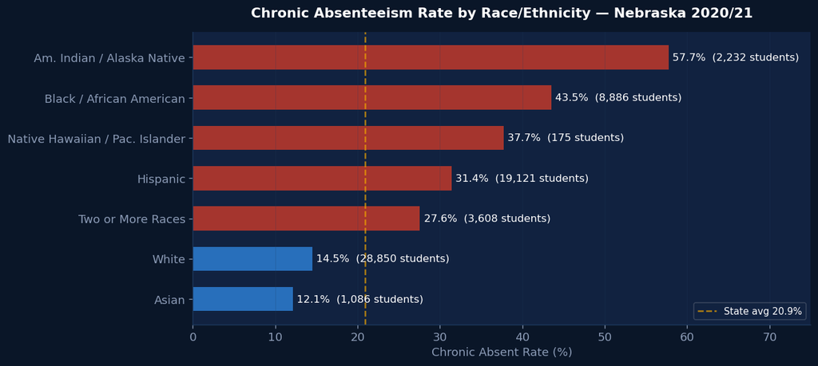

```python
short_names = {
    'AMERICAN INDIAN OR ALASKA NATIVE':        'Am. Indian / Alaska Native',
    'ASIAN':                                    'Asian',
    'BLACK OR AFRICAN AMERICAN':               'Black / African American',
    'HISPANIC':                                 'Hispanic',
    'NATIVE HAWAIIAN OR OTHER PACIFIC ISLANDER':'Native Hawaiian / Pac. Islander',
    'TWO OR MORE RACES':                        'Two or More Races',
    'WHITE':                                    'White',
}

# ── CHART 6: Chronic rate by race — horizontal ranked bar ────────────────
race_sorted = by_race.sort_values('chronic_pct', ascending=True).reset_index(drop=True)
race_sorted['label'] = race_sorted['group'].map(short_names).fillna(race_sorted['group'])

fig, ax = plt.subplots(figsize=(11, 5))
bar_colors = [RED if v > 20.9 else BLUE for v in race_sorted['chronic_pct']]
bars = ax.barh(race_sorted['label'], race_sorted['chronic_pct'],
               color=bar_colors, alpha=0.85, height=0.6, edgecolor='none')
for bar, val, n in zip(bars, race_sorted['chronic_pct'], race_sorted['chronic_n']):
    ax.text(bar.get_width()+0.5, bar.get_y()+bar.get_height()/2,
            f'{val:.1f}%  ({int(n):,} students)', va='center', fontsize=10, color='white')
ax.axvline(20.9, color=AMBER, linestyle='--', linewidth=1.5, alpha=0.7, label='State avg 20.9%')
ax.set_xlabel('Chronic Absent Rate (%)')
ax.set_xlim(0, 75)
ax.set_title('Chronic Absenteeism Rate by Race/Ethnicity — Nebraska 2020/21', pad=14)
ax.legend(fontsize=9, framealpha=0.2)
ax.grid(axis='x', alpha=0.3)
plt.tight_layout()
plt.savefig('fig06_race_bar.png', bbox_inches='tight', facecolor=NAVY)
plt.show()
```

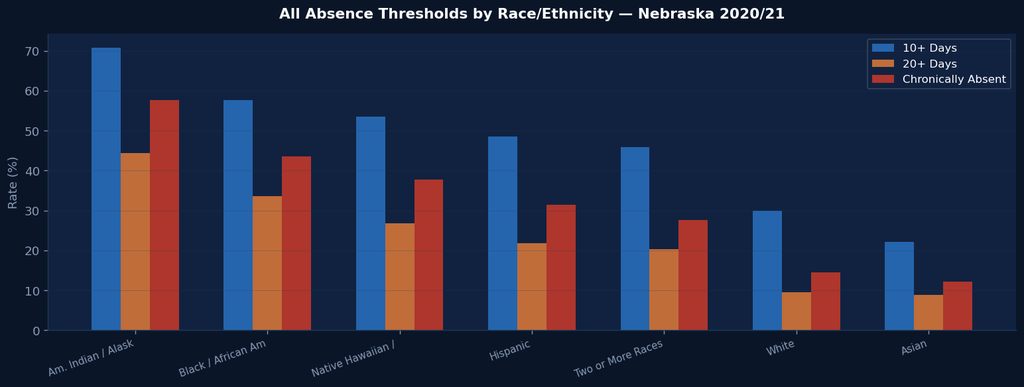

```python
# ── CHART 7: All thresholds by race — grouped bar ─────────────────────────
race_sorted2 = by_race.sort_values('chronic_pct', ascending=False).reset_index(drop=True)
race_sorted2['label'] = race_sorted2['group'].map(short_names).fillna(race_sorted2['group'])
labels_r = [l[:18] for l in race_sorted2['label']]

x = np.arange(len(labels_r)); w = 0.22
fig, ax = plt.subplots(figsize=(13, 5))
ax.bar(x - w,   race_sorted2['pct10'],       width=w, label='10+ Days',          color=BLUE,   alpha=0.75)
ax.bar(x,       race_sorted2['pct20'],       width=w, label='20+ Days',          color=ORANGE, alpha=0.85)
ax.bar(x + w,   race_sorted2['chronic_pct'], width=w, label='Chronically Absent', color=RED,    alpha=0.9)
ax.set_xticks(x); ax.set_xticklabels(labels_r, rotation=20, ha='right', fontsize=9)
ax.set_ylabel('Rate (%)')
ax.set_title('All Absence Thresholds by Race/Ethnicity — Nebraska 2020/21', pad=14)
ax.legend(fontsize=10, framealpha=0.2)
ax.grid(axis='y', alpha=0.3)
plt.tight_layout()
plt.savefig('fig07_race_thresholds.png', bbox_inches='tight', facecolor=NAVY)
plt.show()
```

## 7. Poverty & Special Education

**Key question:** How does economic disadvantage compound absenteeism?

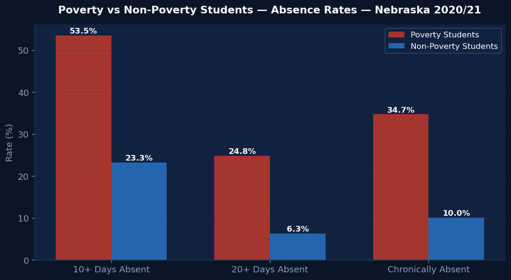

```
Poverty students  : 134,310 (43.8% of total)
Poverty chronic % : 34.7%
Non-pov chronic % : 10.0%
Ratio             : 3.5x higher
```

```python
pov = by_poverty[by_poverty['group']=='POVERTY'].iloc[0]
sped = by_poverty[by_poverty['group']=='SPECIAL EDUCATION'].iloc[0]

non_pov_membership  = TOTAL_ENROLLED - pov['membership']
non_pov_chronic_pct = (CHRONIC_TOTAL - pov['chronic_n']) / non_pov_membership * 100
non_pov_abs10_pct   = (ABS10_TOTAL   - pov['abs10'])    / non_pov_membership * 100
non_pov_abs20_pct   = (ABS20_TOTAL   - pov['abs20'])    / non_pov_membership * 100

# ── CHART 8: Poverty vs non-poverty — all thresholds ─────────────────────
thresholds   = ['10+ Days Absent', '20+ Days Absent', 'Chronically Absent']
pov_rates    = [pov['pct10'], pov['pct20'], pov['chronic_pct']]
nonpov_rates = [non_pov_abs10_pct, non_pov_abs20_pct, non_pov_chronic_pct]

x = np.arange(3); w = 0.35
fig, ax = plt.subplots(figsize=(9, 5))
bars1 = ax.bar(x - w/2, pov_rates,    width=w, label='Poverty Students',     color=RED,  alpha=0.85)
bars2 = ax.bar(x + w/2, nonpov_rates, width=w, label='Non-Poverty Students', color=BLUE, alpha=0.75)
for bars in [bars1, bars2]:
    for bar in bars:
        ax.text(bar.get_x()+bar.get_width()/2, bar.get_height()+0.5,
                f'{bar.get_height():.1f}%', ha='center', fontsize=10, fontweight='bold', color='white')
ax.set_xticks(x); ax.set_xticklabels(thresholds, fontsize=11)
ax.set_ylabel('Rate (%)')
ax.set_title('Poverty vs Non-Poverty Students — Absence Rates — Nebraska 2020/21', pad=14)
ax.legend(fontsize=10, framealpha=0.2)
ax.grid(axis='y', alpha=0.3)
plt.tight_layout()
plt.savefig('fig08_poverty_compare.png', bbox_inches='tight', facecolor=NAVY)
plt.show()
print(f'Poverty students  : {int(pov["membership"]):,} ({pov["membership"]/TOTAL_ENROLLED*100:.1f}% of total)')
print(f'Poverty chronic % : {pov["chronic_pct"]:.1f}%')
print(f'Non-pov chronic % : {non_pov_chronic_pct:.1f}%')
print(f'Ratio             : {pov["chronic_pct"]/non_pov_chronic_pct:.1f}x higher')
```

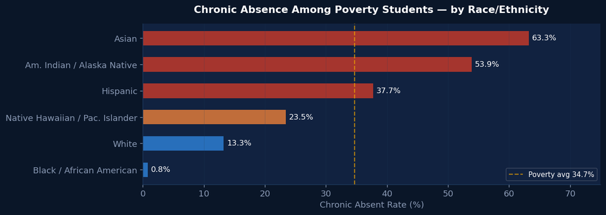

```python
# ── CHART 9: Poverty students by race — chronic rate ─────────────────────
pov_race = by_pov_race.copy()
pov_race['label'] = pov_race['group'].map(short_names).fillna(pov_race['group'])
pov_race_clean = pov_race[pov_race['chronic_pct'] <= 90].sort_values('chronic_pct', ascending=True)

fig, ax = plt.subplots(figsize=(11, 4))
bar_colors = [RED if v > pov['chronic_pct'] else ORANGE if v > 20 else BLUE
              for v in pov_race_clean['chronic_pct']]
bars = ax.barh(pov_race_clean['label'], pov_race_clean['chronic_pct'],
               color=bar_colors, alpha=0.85, height=0.55, edgecolor='none')
for bar, val in zip(bars, pov_race_clean['chronic_pct']):
    ax.text(bar.get_width()+0.5, bar.get_y()+bar.get_height()/2,
            f'{val:.1f}%', va='center', fontsize=10, color='white')
ax.axvline(pov['chronic_pct'], color=AMBER, linestyle='--', linewidth=1.4,
           alpha=0.7, label=f'Poverty avg {pov["chronic_pct"]:.1f}%')
ax.set_xlabel('Chronic Absent Rate (%)')
ax.set_xlim(0, 75)
ax.set_title('Chronic Absence Among Poverty Students — by Race/Ethnicity', pad=14)
ax.legend(fontsize=9, framealpha=0.2)
ax.grid(axis='x', alpha=0.3)
plt.tight_layout()
plt.savefig('fig09_poverty_race.png', bbox_inches='tight', facecolor=NAVY)
plt.show()
```

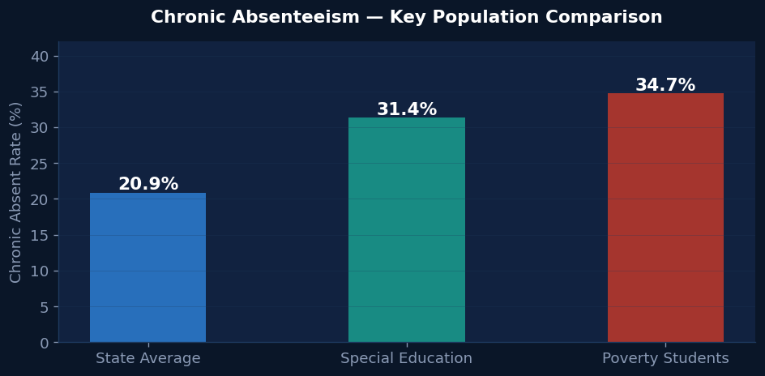

```python
# ── CHART 10: Special Ed vs Poverty vs State avg ─────────────────────────
groups        = ['State Average', 'Special Education', 'Poverty Students']
chronic_rates = [20.9, sped['chronic_pct'], pov['chronic_pct']]
colors_bar    = [BLUE, TEAL, RED]

fig, ax = plt.subplots(figsize=(8, 4))
bars = ax.bar(groups, chronic_rates, color=colors_bar, alpha=0.85, width=0.45, edgecolor='none')
for bar, val in zip(bars, chronic_rates):
    ax.text(bar.get_x()+bar.get_width()/2, bar.get_height()+0.4,
            f'{val:.1f}%', ha='center', fontsize=13, fontweight='bold', color='white')
ax.set_ylabel('Chronic Absent Rate (%)')
ax.set_title('Chronic Absenteeism — Key Population Comparison', pad=14)
ax.set_ylim(0, 42)
ax.grid(axis='y', alpha=0.3)
plt.tight_layout()
plt.savefig('fig10_indicator_compare.png', bbox_inches='tight', facecolor=NAVY)
plt.show()
```

## 8. Gender Breakdown

**Key question:** Is gender a risk factor?

> No — Female (20.8%) and Male (20.9%) are nearly identical. Gender is not a differentiating factor.

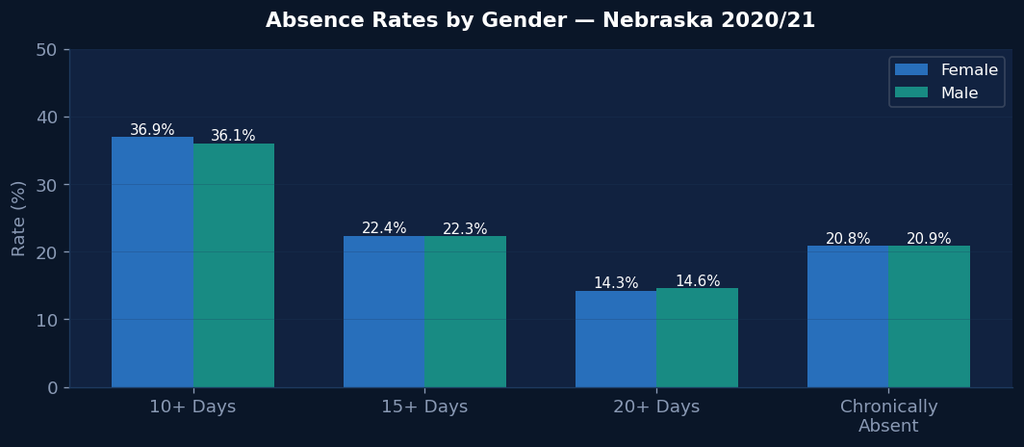

```python
# ── CHART 11: Gender comparison ──────────────────────────────────────────
female = by_gender[by_gender['group']=='FEMALE'].iloc[0]
male   = by_gender[by_gender['group']=='MALE'].iloc[0]

threshold_labels = ['10+ Days', '15+ Days', '20+ Days', 'Chronically\nAbsent']
f_rates = [female['pct10'], female['pct15'], female['pct20'], female['chronic_pct']]
m_rates = [male['pct10'],   male['pct15'],   male['pct20'],   male['chronic_pct']]

x = np.arange(4); w = 0.35
fig, ax = plt.subplots(figsize=(9, 4))
ax.bar(x - w/2, f_rates, width=w, label='Female', color=BLUE,  alpha=0.85)
ax.bar(x + w/2, m_rates, width=w, label='Male',   color=TEAL, alpha=0.85)
for i, (f, m) in enumerate(zip(f_rates, m_rates)):
    ax.text(i-w/2, f+0.4, f'{f:.1f}%', ha='center', fontsize=9, color='white')
    ax.text(i+w/2, m+0.4, f'{m:.1f}%', ha='center', fontsize=9, color='white')
ax.set_xticks(x); ax.set_xticklabels(threshold_labels, fontsize=11)
ax.set_ylabel('Rate (%)')
ax.set_title('Absence Rates by Gender — Nebraska 2020/21', pad=14)
ax.legend(fontsize=10, framealpha=0.2)
ax.set_ylim(0, 50)
ax.grid(axis='y', alpha=0.3)
plt.tight_layout()
plt.savefig('fig11_gender.png', bbox_inches='tight', facecolor=NAVY)
plt.show()
```

## 9. Geography — District & Enrollment Context

**Source:** MembershipByGradeRaceAndGender file.

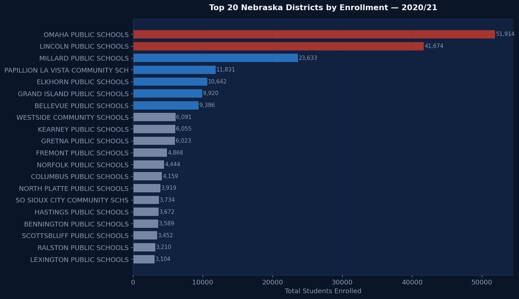

```python
# ── CHART 12: Top 20 districts by enrollment ─────────────────────────────
dist_enroll = mbr.groupby(dist_col)['TOTAL'].sum().reset_index()
dist_enroll.columns = ['district', 'total']
top20 = dist_enroll.nlargest(20, 'total').reset_index(drop=True)

fig, ax = plt.subplots(figsize=(12, 7))
bar_colors = [RED if i < 2 else BLUE+'cc' if i < 7 else MUTED+'88' for i in range(len(top20))]
bars = ax.barh([str(n)[:32] for n in top20['district']], top20['total'],
               color=bar_colors, alpha=0.85, height=0.7, edgecolor='none')
for bar, val in zip(bars, top20['total']):
    ax.text(bar.get_width()+100, bar.get_y()+bar.get_height()/2,
            f'{int(val):,}', va='center', fontsize=9, color=MUTED)
ax.set_xlabel('Total Students Enrolled')
ax.set_title('Top 20 Nebraska Districts by Enrollment — 2020/21', pad=14)
ax.invert_yaxis()
ax.grid(axis='x', alpha=0.3)
plt.tight_layout()
plt.savefig('fig12_top20_districts.png', bbox_inches='tight', facecolor=NAVY)
plt.show()
```

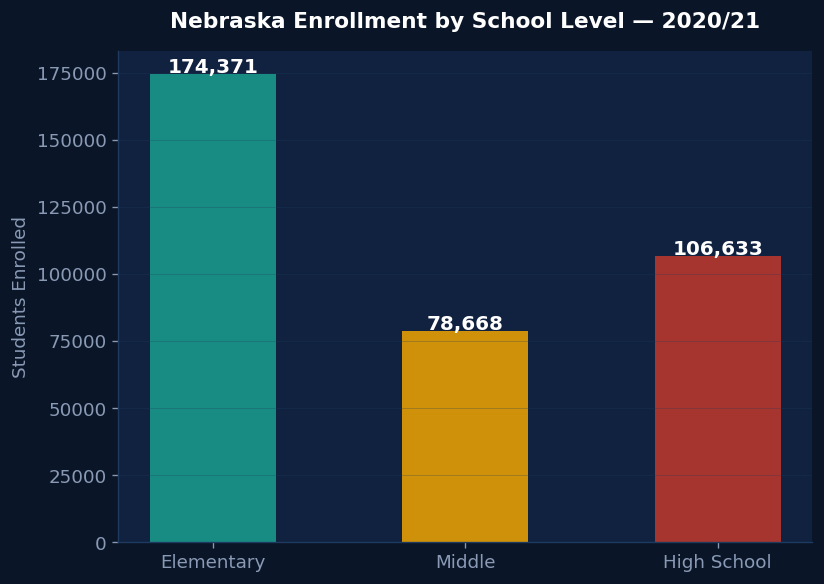

```python
# ── CHART 13: State enrollment by school level ───────────────────────────
level_enroll = (mbr[mbr['level']!='Other']
                .groupby('level')['TOTAL'].sum()
                .reindex(['Elementary','Middle','High School']))

fig, ax = plt.subplots(figsize=(7, 5))
bars = ax.bar(level_enroll.index, level_enroll.values,
              color=[TEAL, AMBER, RED], alpha=0.85, width=0.5, edgecolor='none')
for bar, val in zip(bars, level_enroll):
    ax.text(bar.get_x()+bar.get_width()/2, bar.get_height()+500,
            f'{int(val):,}', ha='center', fontsize=12, fontweight='bold', color='white')
ax.set_ylabel('Students Enrolled')
ax.set_title('Nebraska Enrollment by School Level — 2020/21', pad=14)
ax.grid(axis='y', alpha=0.3)
plt.tight_layout()
plt.savefig('fig13_level_enrollment.png', bbox_inches='tight', facecolor=NAVY)
plt.show()
```

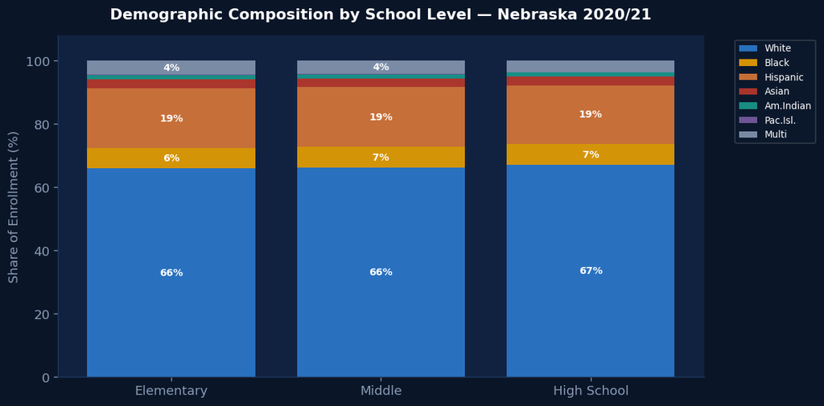

```python
# ── CHART 14: Demographic composition by school level ────────────────────
level_race = (mbr[mbr['level']!='Other']
              .groupby('level')[demo_cols].sum()
              .reindex(['Elementary','Middle','High School']))
level_race_pct = level_race.div(level_race.sum(axis=1), axis=0) * 100

fig, ax = plt.subplots(figsize=(10, 5))
bottom = np.zeros(3)
for i, col in enumerate(demo_cols):
    vals = level_race_pct[col].fillna(0).values
    ax.bar(level_race_pct.index, vals, bottom=bottom,
           label=col, color=(PAL*2)[i], alpha=0.88)
    for j, (v, b) in enumerate(zip(vals, bottom)):
        if v > 4:
            ax.text(j, b+v/2, f'{v:.0f}%', ha='center', va='center',
                    fontsize=8.5, color='white', fontweight='bold')
    bottom += vals
ax.set_ylabel('Share of Enrollment (%)')
ax.set_title('Demographic Composition by School Level — Nebraska 2020/21', pad=14)
ax.legend(loc='upper right', fontsize=8, framealpha=0.2, bbox_to_anchor=(1.18,1))
ax.set_ylim(0, 108)
plt.tight_layout()
plt.savefig('fig14_demo_by_level.png', bbox_inches='tight', facecolor=NAVY)
plt.show()
```

## 10. Absence Escalation Patterns

**Key question:** How does absence severity grow across the student population?

> These charts show which groups carry the highest concentration of severe absence, derived entirely from the attendance file.

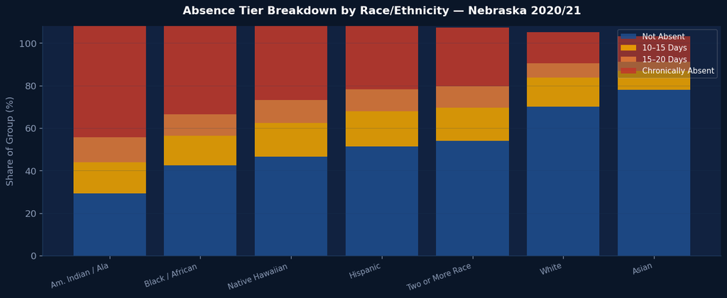

```python
# ── CHART 15: Stacked absence tiers by race ──────────────────────────────
# Shows what share of each race group falls into each absence tier
race_sorted3 = by_race.sort_values('chronic_pct', ascending=False).reset_index(drop=True)
race_sorted3['label'] = race_sorted3['group'].map(short_names).fillna(race_sorted3['group'])

race_sorted3['tier_none']    = 100 - race_sorted3['pct10']
race_sorted3['tier_10_15']   = race_sorted3['pct10']  - race_sorted3['pct15']
race_sorted3['tier_15_20']   = race_sorted3['pct15']  - race_sorted3['pct20']
race_sorted3['tier_chronic'] = race_sorted3['chronic_pct']

tier_cols   = ['tier_none','tier_10_15','tier_15_20','tier_chronic']
tier_labels = ['Not Absent','10–15 Days','15–20 Days','Chronically Absent']
tier_colors = ['#1e4d8c', AMBER, ORANGE, RED]

fig, ax = plt.subplots(figsize=(12, 5))
bottom = np.zeros(len(race_sorted3))
for col, lbl, clr in zip(tier_cols, tier_labels, tier_colors):
    vals = race_sorted3[col].values
    ax.bar(race_sorted3['label'], vals, bottom=bottom, label=lbl,
           color=clr, alpha=0.88, edgecolor='none')
    bottom += vals

ax.set_ylabel('Share of Group (%)')
ax.set_xticklabels([l[:16] for l in race_sorted3['label']], rotation=20, ha='right', fontsize=9)
ax.set_title('Absence Tier Breakdown by Race/Ethnicity — Nebraska 2020/21', pad=14)
ax.legend(fontsize=9, framealpha=0.2, loc='upper right')
ax.set_ylim(0, 108)
ax.grid(axis='y', alpha=0.3)
plt.tight_layout()
plt.savefig('fig15_race_tiers.png', bbox_inches='tight', facecolor=NAVY)
plt.show()
```

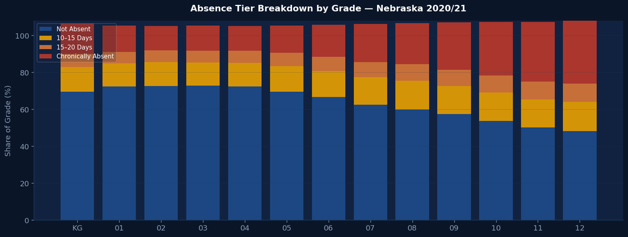

```python
# ── CHART 16: Stacked absence tiers by grade ─────────────────────────────
by_grade['tier_none']    = 100 - by_grade['pct10']
by_grade['tier_10_15']   = by_grade['pct10'] - by_grade['pct15']
by_grade['tier_15_20']   = by_grade['pct15'] - by_grade['pct20']
by_grade['tier_chronic'] = by_grade['chronic_pct']

fig, ax = plt.subplots(figsize=(13, 5))
bottom = np.zeros(len(by_grade))
for col, lbl, clr in zip(tier_cols, tier_labels, tier_colors):
    vals = by_grade[col].values
    ax.bar(by_grade['group'], vals, bottom=bottom, label=lbl,
           color=clr, alpha=0.88, edgecolor='none')
    bottom += vals

ax.set_ylabel('Share of Grade (%)')
ax.set_title('Absence Tier Breakdown by Grade — Nebraska 2020/21', pad=14)
ax.legend(fontsize=9, framealpha=0.2, loc='upper left')
ax.set_ylim(0, 108)
ax.grid(axis='y', alpha=0.3)
plt.tight_layout()
plt.savefig('fig16_grade_tiers.png', bbox_inches='tight', facecolor=NAVY)
plt.show()
```

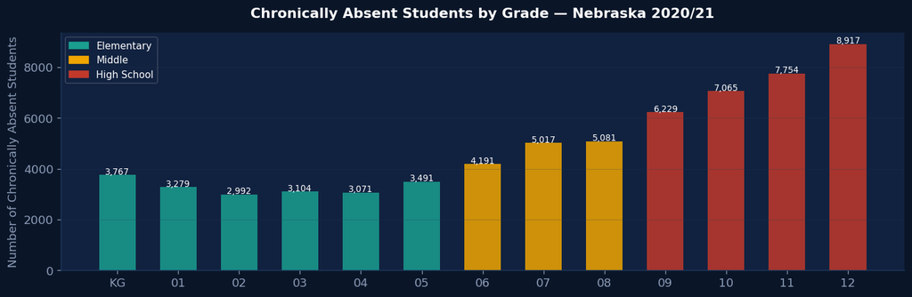

```
Chronic absent by school level:
  Elementary : 19,704
  Middle     : 14,289
  High School: 29,965
```

```python
# ── CHART 17: Chronic absent student count by grade (absolute numbers) ────
fig, ax = plt.subplots(figsize=(12, 4))
bar_colors = [TEAL]*6 + [AMBER]*3 + [RED]*4
bars = ax.bar(by_grade['group'], by_grade['chronic_n'],
              color=bar_colors, alpha=0.85, edgecolor='none', width=0.6)
for bar, val in zip(bars, by_grade['chronic_n']):
    ax.text(bar.get_x()+bar.get_width()/2, bar.get_height()+20,
            f'{int(val):,}', ha='center', fontsize=8, color='white')
ax.set_ylabel('Number of Chronically Absent Students')
ax.set_title('Chronically Absent Students by Grade — Nebraska 2020/21', pad=14)
patches = [mpatches.Patch(color=TEAL, label='Elementary'),
           mpatches.Patch(color=AMBER, label='Middle'),
           mpatches.Patch(color=RED,   label='High School')]
ax.legend(handles=patches, fontsize=9, framealpha=0.2)
ax.grid(axis='y', alpha=0.3)
plt.tight_layout()
plt.savefig('fig17_chronic_count_grade.png', bbox_inches='tight', facecolor=NAVY)
plt.show()
print('Chronic absent by school level:')
print(f'  Elementary : {int(by_grade.iloc[:6]["chronic_n"].sum()):,}')
print(f'  Middle     : {int(by_grade.iloc[6:9]["chronic_n"].sum()):,}')
print(f'  High School: {int(by_grade.iloc[9:]["chronic_n"].sum()):,}')
```

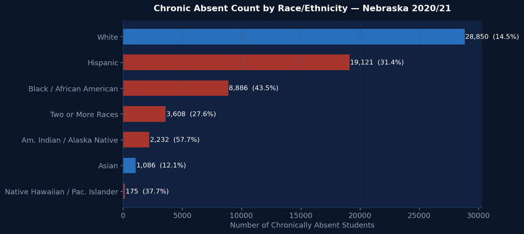

```python
# ── CHART 18: Chronic absent student count by race (absolute) ────────────
by_race['label'] = by_race['group'].map(short_names).fillna(by_race['group'])
race_by_count = by_race.sort_values('chronic_n', ascending=True)

fig, ax = plt.subplots(figsize=(11, 5))
bar_colors2 = [RED if v > 20.9 else BLUE for v in race_by_count['chronic_pct']]
bars = ax.barh(race_by_count['label'], race_by_count['chronic_n'],
               color=bar_colors2, alpha=0.85, height=0.6, edgecolor='none')
for bar, val, pct in zip(bars, race_by_count['chronic_n'], race_by_count['chronic_pct']):
    ax.text(bar.get_width()+50, bar.get_y()+bar.get_height()/2,
            f'{int(val):,}  ({pct:.1f}%)', va='center', fontsize=10, color='white')
ax.set_xlabel('Number of Chronically Absent Students')
ax.set_title('Chronic Absent Count by Race/Ethnicity — Nebraska 2020/21', pad=14)
ax.grid(axis='x', alpha=0.3)
plt.tight_layout()
plt.savefig('fig18_chronic_count_race.png', bbox_inches='tight', facecolor=NAVY)
plt.show()
```

## 11. Key Findings Summary

All findings below are derived directly from the NDE attendance and membership files.

[output not shown]

### Next Phase — Economic Impact (requires external data sources)

To quantify dollar impact, the research will need work on finding factors already defined.